# 15. 回帰分析 2（ダミー変数）

Masahiko Asano

2026-06-29

- 分析に必要なパッケージをロードする

```r
library(estimatr)     # for lm_robust()
library(modelsummary) # for modelsummary()
library(tidyverse)
library(stargazer)
```

# 1. ダミー変数でわかること

## 1.1 ダミー変数とは

- ある属性があるかどうかを示す 2 値変数
- 特定のカテゴリーに属している場合・・・1
- そのカテゴリーに属さない場合・・・0  
  例）
- 性別（女性 = 1、男性 = 0）
- 選挙結果（当選 = 1、落選 = 0）
- 社会の状態（戦時 = 1、平和時 = 0）
- 州の位置（北部 = 1、南部 = 0）などなど・・・

## 1.2 ダミー変数でわかること

- 「9. 回帰分析 1（単回帰と重回帰）」のロバート・パットナムの事例
- 経済状況（横軸）と政府のパフォーマンスの間には正の相関・・・左側の図
- 「イタリア州政府の位置（南北）」という northダミーをモデルに入れる  
  → 経済状況（横軸）と政府のパフォーマンスの間には負の相関（無相関）・・・右側の図

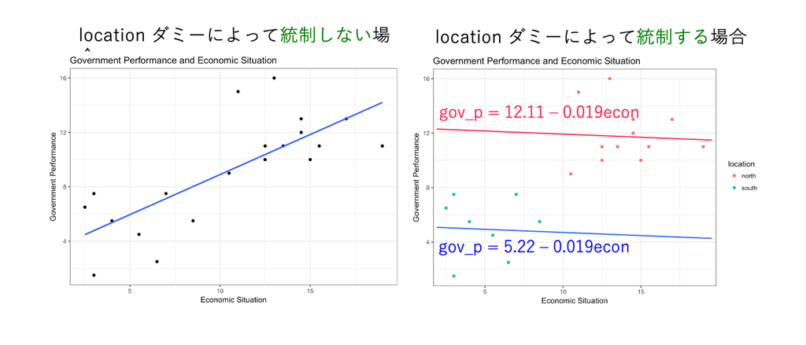

# 2. 南北格差ダミーと経済の近代化

## 2.1 理論と仮説

**リサーチクエスチョン：**  
**「イタリア地方政府のパフォーマンスに著しい違いがあるのはなぜか？」**

**理論：**  
**Social Capital（社会関係資本）が政府のパフォーマンスを高める**

- 地方政府のパフォーマンスの違いは、その地域の社会関係資本の蓄積の度合いによって説明できる
- 「社会関係資本」・・・個人の結びつき → 互恵性の社会ネットワークや規範  
  （＝見知らぬ相手と協力関係を構築する一助となるもの）
- 社会関係資本の蓄積の高い地域  
  → 互いに信頼し協力しあう  
  → 政府のパフォーマンスを高める

**【応答変数】**

- 「政府のパフォーマンス」を作業化 → **gov_p** : 12の指標から構成
1. 地方政府の内閣の安定性
2. 予算通過の早さ
3. 統計- 情報サービスの提供

**【説明変数】**

- 「社会関係資本の蓄積の度合」を作業化 → **cc**: `Civic Community Index`（市民共同体指標）
1. 比例代表での個人名記入投票の割合 = `Clientelism`（政治的恩顧主義）の度合
2. 住民投票での投票率 = 地域社会への関心の度合
3. 新聞購読者の割合 = 市民的な熟慮能力の度合
4. スポーツ- 文化団体の割合 = 市民の社交的生活の度合

**仮説**  
**もしこの理論が正しいなら、**  
**cc（市民共同体指標）が大きくなるほど gov_p（政府のパフォーマンス）も大きくなるはず**

- 応答変数：**gov_p**（政府のパフォーマンス）
- 説明変数：**cc**（Civic Community Index 市民共同体指標）
- コントロール変数：**econ**（地方政府の経済指標）

## 2.2 oldberg による Putnam 批判とその検証

**【イタリアにおける南北格差を考慮すべき】**

- oldberg (1996) による Putnam (1994)への批判
- イタリアにおいて北部と南部とは全く異なる歴史、伝統、文化をもつ
- 政治、経済、社会の状態の違いはすべて南北地域の違いで説明できる
- 社会関係資本の蓄積の度合は、南北の地域の違いを反映している
- 分析において、南北の地域差を考慮する必要がある
- 北部 → 社会関係資本が多い → 政府のパフォーマンスが高い
- 南部 → 社会関係資本が少ない → 政府のパフォーマンスが低い

### 検証 1: 南北によって政府のパフォーマンスは違うのか？

**Question 1:**  
**社会関係資本の蓄積の度合 (`cc`) は南北の地域の違い (`location`) を反映しているだけであって、政府のパフォーマンス (`gov_p`) とは無関係なのでは？**

**データ (`putnam.csv`)**：

| 変数の種類 | 変数名 | 詳細 |
| --- | --- | --- |
|  | `region` | イタリア州政府の略称 |
| 応答変数 | `gov_p` | 政府のパフォーマンス |
| 説明変数 | `cc` | Civic Community Index （市民共同体指標） |
| 制御変数 | `econ` | 地方政府の経済指標（大きい程、経済が良好） |
| 制御変数 | `location` | イタリア北部地域ダミー（北部なら north、南部なら south） |

**✔ ここでは「制御変数」として新たに `location` というダミー変数を を付け加えている**

- このセクションの分析で使うデータ putnam.csvをダウンロードし、`RProject Folder` に保存する

```r
df1 <- read_csv("data/putnam.csv")  # 欠損処理をしないので read_csv を使う
df1
```

```
# A tibble: 20 × 5
   region gov_p    cc  econ location
   <chr>  <dbl> <dbl> <dbl> <chr>
 1 Ab       7.5   8     7   south
 2 Ba       7.5   4     3   south
 3 Cl       1.5   1     3   south
 4 Cm       2.5   2     6.5 south
 5 Em      16    18    13   north
 6 Fr      12    17    14.5 north
 7 La      10    13    12.5 north
 8 Li      11    16    15.5 north
 9 Lo      11    17    19   north
10 Ma       9    15.5  10.5 north
11 Mo       6.5   3.5   2.5 south
12 Pi      13    15.5  17   north
13 Pu       5.5   3.5   4   south
14 Sa       5.5   8.5   8.5 south
15 Si       4.5   3.5   5.5 south
16 To      13    17.5  14.5 north
17 Tr      11    18    12.5 north
18 Um      15    15.5  11   north
19 Va      10    15    15   north
20 Ve      11    15    13.5 north
```

**- 政府のパフォーマンスが南北地域間で異なるかどうか t 検定する**

- 箱ひげ図を描く

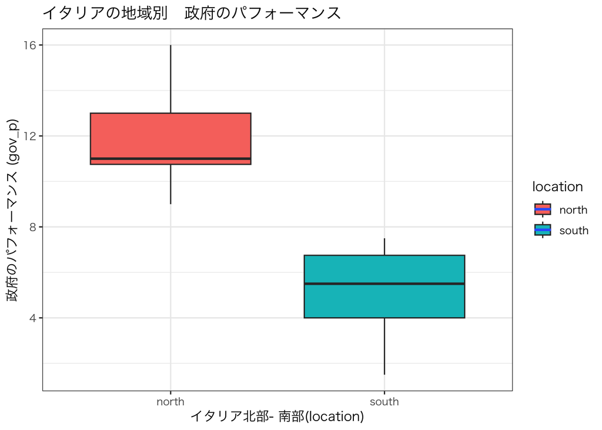

```r
df1 %>%
  ggplot(aes(x = location, y = gov_p, fill = location)) +
    geom_boxplot() +
  labs(x = "イタリア北部- 南部(location)", y = "政府のパフォーマンス (gov_p)",
         title = "イタリアの地域別　政府のパフォーマンス") +
  stat_smooth(method = lm, se = FALSE) +  # se = FALSE → 95% 信頼区間を消す
  theme_bw(base_family = "HiraKakuProN-W3")
```

- 視覚的に南北間で政府のパフォーマンスに明らかに差がある
- 政府のパフォーマンスのデータは `unpaired` だから `default` で `t` 検定する

```r
t.test(df1$gov_p[df1$location == "north"],
       df1$gov_p[df1$location == "south"])
```

```
    Welch Two Sample t-test

data:  df1$gov_p[df1$location == "north"] and df1$gov_p[df1$location == "south"]
t = 6.8253, df = 14.552, p-value = 6.737e-06
alternative hypothesis: true difference in means is not equal to 0
95 percent confidence interval:
 4.607777 8.808890
sample estimates:
mean of x mean of y
 11.83333   5.12500
```

### 検証 2: 南北「内」でも「経済」は「政府のパフォーマンス」を説明できるのか？

**Question 2:**

- **経済の近代化の度合 (econ) が高い地域ほど政府のパフォーマンス (gov_p) が高い。これは南北地域「内」でもみられるか？**
- `econ` と `gov_p` の散布図を描く

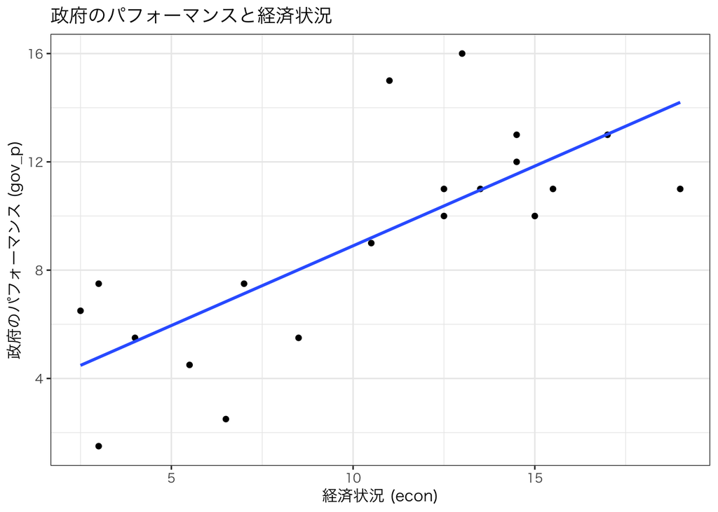

```r
df1 %>%
  ggplot(aes(econ, gov_p)) +
  geom_point() +
  theme_bw() +
  labs(x = "経済状況 (econ)", y = "政府のパフォーマンス (gov_p)",
         title = "政府のパフォーマンスと経済状況") +
  stat_smooth(method = lm, se = FALSE) +  # se = FALSE → 95% 信頼区間を消す
  theme_bw(base_family = "HiraKakuProN-W3")
```

- 経済の近代化の度合いと政府のパフォーマンス (`gov_p`) には正の相関がある
- `econ` と `gov_p` には正の相関がある  
  **- 地方政府の経済指標 (`econ`) が高い地域ほど、政府のパフォーマンス (`gov_p`) が高い**
- 回帰式を求める

```r
model_1 <- lm(gov_p ~ econ, data = df1)

summary(model_1)
```

```
Call:
lm(formula = gov_p ~ econ, data = df1)

Residuals:
    Min      1Q  Median      3Q     Max
-4.3386 -1.7733  0.0086  0.8336  5.5114

Coefficients:
            Estimate Std. Error t value Pr(>|t|)
(Intercept)   3.0108     1.3847   2.174 0.043264 *
econ          0.5889     0.1200   4.909 0.000113 ***
---
Signif. codes:  0 '***' 0.001 '**' 0.01 '*' 0.05 '.' 0.1 ' ' 1

Residual standard error: 2.659 on 18 degrees of freedom
Multiple R-squared:  0.5724,    Adjusted R-squared:  0.5487
F-statistic:  24.1 on 1 and 18 DF,  p-value: 0.0001131
```

$$\widehat{gov_p}\ = 3.01 +
0.589econ$$
- `df1` に含まれる変数の型をチェックする

```r
str(df1)
```

```
spc_tbl_ [20 × 5] (S3: spec_tbl_df/tbl_df/tbl/data.frame)
 $ region  : chr [1:20] "Ab" "Ba" "Cl" "Cm" ...
 $ gov_p   : num [1:20] 7.5 7.5 1.5 2.5 16 12 10 11 11 9 ...
 $ cc      : num [1:20] 8 4 1 2 18 17 13 16 17 15.5 ...
 $ econ    : num [1:20] 7 3 3 6.5 13 14.5 12.5 15.5 19 10.5 ...
 $ location: chr [1:20] "south" "south" "south" "south" ...
 - attr(*, "spec")=
  .. cols(
  ..   region = col_character(),
  ..   gov_p = col_double(),
  ..   cc = col_double(),
  ..   econ = col_double(),
  ..   location = col_character()
  .. )
 - attr(*, "problems")=<pointer: 0x10df46e60>
```

- `df1` に含まれる変数 `location` は `charactor` なので、0, 1 のダミー変数 `north` を付け加える
- 変換後のデータフレームは `df1` のまま

```r
df1 <- df1 |>
  mutate(north = if_else(location == "north", 1, 0))
                               # north = 1, south = 0 に変換
head(df1) #変換したデータをの一部を表示
```

```
# A tibble: 6 × 6
  region gov_p    cc  econ location north
  <chr>  <dbl> <dbl> <dbl> <chr>    <dbl>
1 Ab       7.5     8   7   south        0
2 Ba       7.5     4   3   south        0
3 Cl       1.5     1   3   south        0
4 Cm       2.5     2   6.5 south        0
5 Em      16      18  13   north        1
6 Fr      12      17  14.5 north        1
```

**- 経済の近代化の度合 (`econ`) が高い地域ほど、政府のパフォーマンス (`gov_p`) が高い**  
**- これが南北地域「内」でもみられるかどうかを確認するためには、**

**→モデルに `econ` と `north` ダミーを同時に入れて重回帰分析を行う必要がある**

```r
model_2 <- lm(gov_p ~ econ + north, data = df1)
```

- 分析結果を表示する

```r
summary(model_2)
```

```
Call:
lm(formula = gov_p ~ econ + north, data = df1)

Residuals:
    Min      1Q  Median      3Q     Max
-3.6638 -1.1011 -0.2199  1.2497  4.1464

Coefficients:
            Estimate Std. Error t value Pr(>|t|)
(Intercept)  5.22207    1.34660   3.878  0.00121 **
econ        -0.01941    0.22037  -0.088  0.93083
north        6.88386    2.22907   3.088  0.00667 **
---
Signif. codes:  0 '***' 0.001 '**' 0.01 '*' 0.05 '.' 0.1 ' ' 1

Residual standard error: 2.19 on 17 degrees of freedom
Multiple R-squared:  0.7261,    Adjusted R-squared:  0.6939
F-statistic: 22.53 on 2 and 17 DF,  p-value: 1.659e-05
```

- この結果から、次の標本回帰関数 (`SRF`) の回帰式が得られる

$$\widehat{gov_p}\ = 5.22 - 0.019econ +
6.88north$$

- 経済の近代化の度合 (`econ`) は `gov_p` に有意な影響を与えていない
- 北部地域だと `gov_p` を 6.88 ポイント上げる 1% 水準で有意
- `north` ダミーによって統制すると、次の 2 つの**（傾きの等しい）**回帰式を得る

**南部 (north = 0) なら、**

$$\widehat{gov_p}\ = 5.22 -
0.019econ$$

**北部 (north = 1) なら、**

$$\widehat{gov_p}\ = 12.11 -
0.019econ$$

- 以上の結果を散布図で表してみる

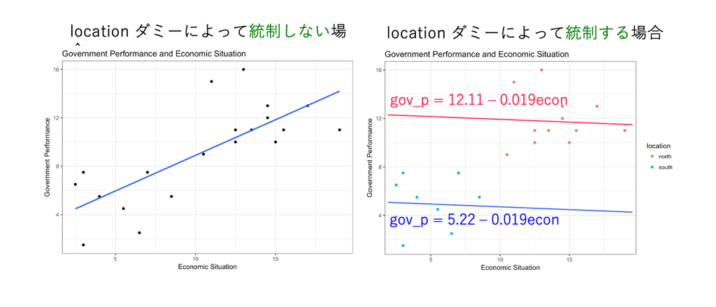

- **全体で見ると（上図左）**  
  → 経済の近代化の度合 (`econ`)が高くなるにつれて政府のパフォーマンス (`gov_p`) が高い
- **南北地域別に見ると（上図右）**  
  → 経済の近代化の度合 (`econ`) は政府のパフォーマンス (`gov_p`) に影響を与えていない
- `location` は 1% 水準で統計的に有意 (`p-value = 0.00667`)  
  → 北部地域の方が南部地域より `gov_p` が 6.88 ポイント高い
- `econ` は 5% 水準でも統計的に有意ではない  
  → **南北地域ダミー (`north`) を考慮すると**  
  → 経済の近代化の度合 (`econ`) が政府のパフォーマンス (`gov_p`) に対する影響が消える

**→ 経済の近代化の度合 (`econ`) と政府のパフォーマンス (`gov_p`)は偽の関係 (`spurious correlation`)**

Question 2 結果 ・南北地域ダミー (`north`) を考慮すると、南北「内」で「経済の近代化の度合」は「政府のパフォーマンス」を説明できない

### 検証 3: 政府のパフォーマンスを説明するのは「経済」「南北」「社会関係資本」？

**Question 3:**  
**社会関係資本 (`cc`) が政府のパフォーマンス (`gov_p`) に影響を与えるという Putnam (1994) の主張は、南北地域差 (`north`) を考慮しても成立するのか？**

- `cc` と `gov_p` の散布図を描く
- ggplot で日本語を表示したい場合には、マックユーザーは以下の行を入力

```r
theme_bw(base_family = "HiraKakuProN-W3")
```

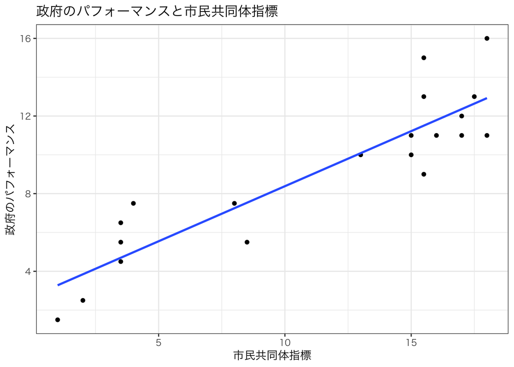

```r
df1 %>%
  ggplot(aes(cc, gov_p)) +
  geom_point() +
  labs(x = "市民共同体指標", y = "政府のパフォーマンス",
         title = "政府のパフォーマンスと市民共同体指標") +
  stat_smooth(method = lm, se = FALSE)  + # se = FALSE → 95% 信頼区間を消す
  theme_bw(base_family = "HiraKakuProN-W3")
```

- `cc` と `gov_p` には正の相関がある  
  **- 社会関係資本 (`cc`) が高い地域ほど、政府のパフォーマンス (`gov_p`) が高い**
- 回帰式を求めると

```r
model_3 <- lm(gov_p ~ cc, data = df1)

summary(model_3)
```

```
Call:
lm(formula = gov_p ~ cc, data = df1)

Residuals:
    Min      1Q  Median      3Q     Max
-2.5043 -1.3481 -0.2087  0.9764  3.4957

Coefficients:
            Estimate Std. Error t value Pr(>|t|)
(Intercept)  2.71115    0.84443   3.211  0.00485 **
cc           0.56730    0.06552   8.658 7.81e-08 ***
---
Signif. codes:  0 '***' 0.001 '**' 0.01 '*' 0.05 '.' 0.1 ' ' 1

Residual standard error: 1.789 on 18 degrees of freedom
Multiple R-squared:  0.8064,    Adjusted R-squared:  0.7956
F-statistic: 74.97 on 1 and 18 DF,  p-value: 7.806e-08
```

$$\widehat{gov_p}\ = 2.711 +
0.567cc$$

- 社会関係資本 (`cc`) が 1 単位増えると、政府のパフォーマンス (`gov_p`) が0.567ポイント上昇する
- これは偶然とは考えられない（← `p-value が 7.81e-08`）  
  **- これが南北地域「内」でもみられるかどうかを確認するためには、**  
  **→モデルに `cc` と `north` ダミーを同時に入れて重回帰分析を行う必要がある**

```r
model_4 <- lm(gov_p ~ cc + north, data = df1)
```

- 分析結果を表示する

```r
summary(model_4)
```

```
Call:
lm(formula = gov_p ~ cc + north, data = df1)

Residuals:
    Min      1Q  Median      3Q     Max
-2.5003 -1.3445 -0.2058  0.9773  3.4997

Coefficients:
            Estimate Std. Error t value Pr(>|t|)
(Intercept)  2.69850    1.12131   2.407   0.0278 *
cc           0.57094    0.21485   2.657   0.0166 *
north       -0.04781    2.67759  -0.018   0.9860
---
Signif. codes:  0 '***' 0.001 '**' 0.01 '*' 0.05 '.' 0.1 ' ' 1

Residual standard error: 1.841 on 17 degrees of freedom
Multiple R-squared:  0.8064,    Adjusted R-squared:  0.7836
F-statistic:  35.4 on 2 and 17 DF,  p-value: 8.689e-07
```

- この結果から、次の標本回帰関数 (`SRF`) の回帰式が得られる
  $$\widehat{gov_p}\ = 2.7 + 0.57cc -
  0.048north$$
- 社会関係資本 (`cc`) は `gov_p` に有意な影響を与えている 5%水準で有意
- `north` ダミーは `gov_p` に影響を与えていない
- `north` ダミーによって統制すると、次の 2 つの**（傾きの等しい）**回帰式を得る

**南部 (`north = 0`) なら、**

$$\widehat{gov_p}\ = 2.7 +
0.57cc$$

**北部 (`north = 1`) なら、**

$$\widehat{gov_p}\ = 2.65 +
0.57cc$$

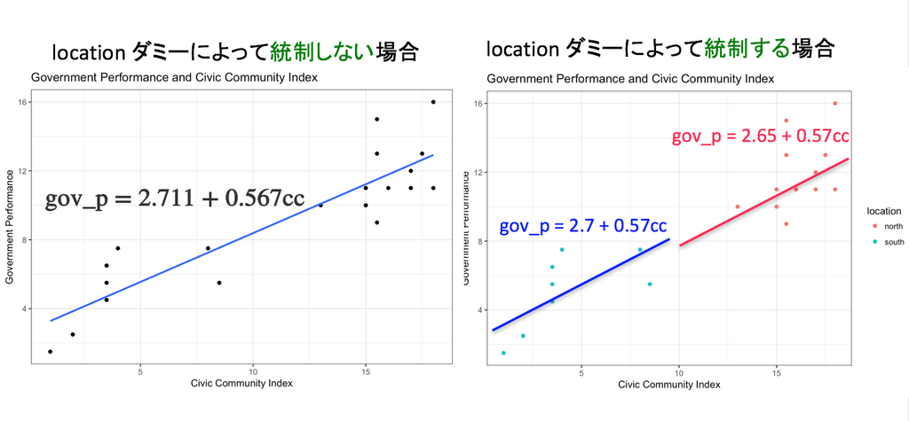

- **全体で見ると（上図左）**  
  → 社会関係資本 (`cc`) が高くなるにつれて政府のパフォーマンス (`gov_p`) が高い
- **南北地域別に見ても（上図右）**  
  → 社会関係資本 (`cc`)が高くなるにつれて政府のパフォーマンス (`gov_p`) が高い
- `north` は 5% 水準で統計的に有意ではない (`p-value = 0.9860`)
- `cc` は 5% 水準でも統計的に有意 (`p-value = 0.0166`)
- 南北地域ダミー (`north`) を考慮しても、  
  → 社会関係資本 (`cc`) が政府のパフォーマンス (`gov_p`) に対して影響を与えている

Question 3 結果 ・同レベルの社会関係資本 (`cc`) をもつ自治体では、北部であろうが南部であろうが、政府のパフォーマンス (`gov_p`) の高さに違いはない  
・政府のパフォーマンス (`gov_p`) は「南北地域の違い」(`north`) によってではなく「社会関係資本」(`cc`) によって説明される

# 3. ダミー変数でわかること（総選挙）

- 日本の衆議院選挙結果データを使った次のモデルを考えてみよう

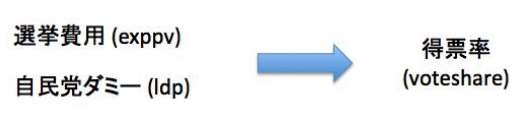

## 3.1 データの準備 (`hr96-26.csv`)

### 3.1.1 データのダウンロード方法

#### 予めダウンロード先を指定する方法

- `RProject` フォルダ内に **data** という名称のフォルダを作成する
- 下のコマンドを実行すると、`csv` ファイルがパソコンにダウンロードされ、**data** 内に自動的に保存される

```r
download.file(url = "https://asanoucla.github.io/hr96-26.csv",
              destfile = "data/hr96-26.csv")
```

注意：一度ダウンロードを完了すれば、このコマンドを実行する必要はありません

#### ダウンロード先を指定しない方法

- hr96-26.csv をクリックしてデータをパソコンにダウンロード
- `RProject` フォルダ内に **data** という名称のフォルダを作成する
- ダウンロードした `hr96-26.csv` を手動で`RProject` フォルダ内にある **data** フォルダに入れる

### 3.1.2 選挙データの読み取り方法

- 次の**いずれかの方法で** `hr96-26.csv` を読み取る

##### 読み取り方法 1

- `na = "."`というコマンドは「欠損値をドットで置き換える」という意味
- 欠損値を空欄のまま残すと、本来「数値 (`numeric`)」型のデータが「」文字型 (`character`)」として認識されるなど、エラーの原因になるため、読み取る時点で事前に対処する

```r
hr <- read_csv("data/hr96-26.csv",
               na = ".")
```

##### 読み取り方法 2

- 読み取った値の日本語が文字化けする場合
- `locale()`関数を使って日本語エンコーディング (`cp932`) を指定する

```r
hr <- read_csv("data/hr96-26.csv",
               na = ".",
               locale = locale(encoding = "cp932"))
```

##### 読み取り方法 3

```r
hr <- read.csv("data/hr96-26.csv",
               na = ".")
```

### 3.1.3 読み取った選挙データを確認

- `hr96-26.csv` は1996年に衆院選挙に小選挙区が導入されて以来実施された 11 回の衆議院選挙（1996, 2000, 2003, 2005, 2009, 2012, 2014, 2017, 2021, 2024, 2026）の結果のデータ
- `hr` に含まれる変数名を表示させる

```r
names(hr)
```

```
 [1] "year"          "pref"          "ku"            "kun"
 [5] "rank"          "wl"            "nocand"        "seito"
 [9] "j_name"        "name"          "previous"      "gender"
[13] "age"           "exp"           "status"        "vote"
[17] "voteshare"     "eligible"      "turnout"       "seshu_dummy"
[21] "jiban_seshu"   "nojiban_seshu"
```

- `df1` には 22 個の変数が入っている

| 変数名 | 詳細 |
| --- | --- |
| year | 選挙年 (1996-2026) |
| pref | 都道府県名 |
| ku | 小選挙区名 |
| kun | 小選挙区 |
| rank | 当選順位 |
| wl | 選挙の当落: 1 = 小選挙区当選、2 = 復活当選、0 = 落選 |
| nocand | 立候補者数 |
| seito | 候補者の所属政党 |
| j_name | 候補者の氏名（日本語） |
| name | 候補者の氏名（ローマ字） |
| previous | これまでの当選回数（当該総選挙結果は含まない） |
| gender | 立候補者の性別: “male”, “female” |
| age | 立候補者の年齢 |
| exp | 立候補者が使った選挙費用（総務省届け出） |
| status | 候補者のステータス: 0 = 非現職、1 現職、2 = 元職 |
| vote | 得票数 |
| voteshare | 得票率 (%) |
| eligible | 小選挙区の有権者数 |
| turnout | 小選挙区の投票率 (%) |
| seshu_dummy | 世襲候補者ダミー: 1 = 世襲、0 = 非世襲（地盤世襲 or 非世襲） |
| jiban_seshu | 地盤の受け継ぎ元の政治家の氏名と関係 |
| nojiban_seshu | 世襲元の政治家の氏名と関係 |

- データの型をチェック

```r
str(hr)
```

```
spc_tbl_ [11,892 × 22] (S3: spec_tbl_df/tbl_df/tbl/data.frame)
 $ year         : num [1:11892] 1996 1996 1996 1996 1996 ...
 $ pref         : chr [1:11892] "愛知" "愛知" "愛知" "愛知" ...
 $ ku           : chr [1:11892] "aichi" "aichi" "aichi" "aichi" ...
 $ kun          : num [1:11892] 1 1 1 1 1 1 1 2 2 2 ...
 $ rank         : num [1:11892] 7 6 5 4 3 2 1 8 7 6 ...
 $ wl           : num [1:11892] 0 0 0 0 0 0 1 0 0 0 ...
 $ nocand       : num [1:11892] 7 7 7 7 7 7 7 8 8 8 ...
 $ seito        : chr [1:11892] "無所" "国民党" "文化フォーラム" "共産" ...
 $ j_name       : chr [1:11892] "浅野光雪" "山田浩" "伊東マサコ" "岩中美保子" ...
 $ name         : chr [1:11892] "ASANO, KOSETSU" "YAMADA, HIROSHI" "ITO, MASAKO" "IWANAKA, MIHOKO" ...
 $ previous     : num [1:11892] 0 0 0 0 1 3 1 0 0 0 ...
 $ gender       : chr [1:11892] "male" "male" "female" "female" ...
 $ age          : num [1:11892] 45 51 51 43 53 72 47 43 47 61 ...
 $ exp          : num [1:11892] NA NA NA 2177203 9231284 ...
 $ status       : num [1:11892] 0 0 0 0 1 2 1 0 0 0 ...
 $ vote         : num [1:11892] 312 566 616 22209 33503 ...
 $ voteshare    : num [1:11892] 0.2 0.3 0.4 13.3 20.1 25.7 40 0.2 0.2 0.4 ...
 $ eligible     : num [1:11892] 346774 346774 346774 346774 346774 ...
 $ turnout      : num [1:11892] 49.2 49.2 49.2 49.2 49.2 49.2 49.2 51.8 51.8 51.8 ...
 $ seshu_dummy  : num [1:11892] 0 0 0 0 0 0 0 0 0 0 ...
 $ jiban_seshu  : chr [1:11892] NA NA NA NA ...
 $ nojiban_seshu: chr [1:11892] NA NA NA NA ...
 - attr(*, "spec")=
  .. cols(
  ..   year = col_double(),
  ..   pref = col_character(),
  ..   ku = col_character(),
  ..   kun = col_double(),
  ..   rank = col_double(),
  ..   wl = col_double(),
  ..   nocand = col_double(),
  ..   seito = col_character(),
  ..   j_name = col_character(),
  ..   name = col_character(),
  ..   previous = col_double(),
  ..   gender = col_character(),
  ..   age = col_double(),
  ..   exp = col_double(),
  ..   status = col_double(),
  ..   vote = col_double(),
  ..   voteshare = col_double(),
  ..   eligible = col_double(),
  ..   turnout = col_double(),
  ..   seshu_dummy = col_double(),
  ..   jiban_seshu = col_character(),
  ..   nojiban_seshu = col_character()
  .. )
 - attr(*, "problems")=<pointer: 0x11907aba0>
```

- 数値は `numeric` 文字は `character` として認識されていることがわかる

## 3.2 データの作成と記述統計

- `hr96-26.csv` は1996年に衆院選挙に小選挙区が導入されて以来実施された 11 回の衆議院選挙（1996, 2000, 2003, 2005, 2009, 2012, 2014, 2017, 2021, 2024, 2026）の結果データ
- `hr` に含まれる変数を確認する

```r
names(hr)
```

```
 [1] "year"          "pref"          "ku"            "kun"
 [5] "rank"          "wl"            "nocand"        "seito"
 [9] "j_name"        "name"          "previous"      "gender"
[13] "age"           "exp"           "status"        "vote"
[17] "voteshare"     "eligible"      "turnout"       "seshu_dummy"
[21] "jiban_seshu"   "nojiban_seshu"
```

- `hr` には 22 個の変数が入っていることがわかる
- これらの変数を使って、分析に必要な新たな変数 (`exppv`, `ldp`) をつくる

**exppv （有権者一人あたり選挙費用）の作成**

- `exp` と `eligible` のデータ型を確認する

```r
str(hr$exp)
```

```
 num [1:11892] NA NA NA 2177203 9231284 ...
```

```r
str(hr$eligible)
```

```
 num [1:11892] 346774 346774 346774 346774 346774 ...
```

- どちらも数値型 (`numeric`) で問題ない
- `exp` と `eligible` を使って、有権者 1 人あたりに使う選挙費用 (`exppv`) を作る

```r
hr <- hr %>%
  dplyr::mutate(exppv = exp/eligible) # eligible は小選挙区ごとの有権者数
```

```r
summary(hr$exppv)
```

```
     Min.   1st Qu.    Median      Mean   3rd Qu.      Max.       NAs
1.264e-03 7.749e+00 1.748e+01 2.141e+01 3.021e+01 1.192e+02      2413
```

**ldp（自民党ダミー）の作成**

- `seito` に含まれる値を確かめる

```r
unique(hr$seito)
```

```
 [1] "無所"                   "国民党"                 "文化フォーラム"
 [4] "共産"                   "民主"                   "自民"
 [7] "新進"                   "自由連合"               "政事公団太平会"
[10] "社民"                   "新社会"                 "日本新進"
[13] "新党さきがけ"           "青年自由"               "さわやか神戸・市民の会"
[16] "民主改革連合"           "市民新党にいがた"       "沖縄社会大衆党"
[19] "緑の党"                 "諸派"                   "公明"
[22] "保守"                   "無所属の会"             "自由"
[25] "改革クラブ"             "保守新"                 "新党尊命"
[28] "ニューディールの会"     "世界経済共同体党"       "新党日本"
[31] "国民新党"               "新党大地"               "幸福"
[34] "みんな"                 "改革"                   "日本未来"
[37] "日本維新の会"           "当たり前"               "アイヌ民族党"
[40] "政治団体代表"           "安楽死党"               "次世"
[43] "維新"                   "生活"                   "希望"
[46] "立憲"                   "緒派"                   "Ｎ党"
[49] "国民"                   "れい"                   "参政"
[52] "中道"                   "減ゆ"                   "れいわ"
[55] "みらい"
```

- 分析には自民党ダミーが必要なので、`if_else()`関数を使って `LDP = 1`, それ以外の政党を 0 にしたダミー変数を作り `hr` に付け加える

```r
hr <- hr %>%
  mutate(ldp = if_else(seito == "自民", 1, 0))
```

**小選挙区を表す変数 `district` の作成**  
- `ku` + `kun` => `district`  
- 例）`aichi` + `1` => `aichi_1`

```r
hr <- hr %>%
  mutate(district = str_c(ku, kun, sep = "_"))
```

**注：`district` 変数は「3.7 頑強な標準誤差を使った回帰分析」で使います**

- `hr` に含まれる変数を確認する

```r
names(hr)
```

```
 [1] "year"          "pref"          "ku"            "kun"
 [5] "rank"          "wl"            "nocand"        "seito"
 [9] "j_name"        "name"          "previous"      "gender"
[13] "age"           "exp"           "status"        "vote"
[17] "voteshare"     "eligible"      "turnout"       "seshu_dummy"
[21] "jiban_seshu"   "nojiban_seshu" "exppv"         "ldp"
[25] "district"
```

| 変数名 | 詳細 |
| --- | --- |
| year | 選挙年 (1996-2026) |
| pref | 都道府県名 |
| ku | 小選挙区名 |
| kun | 小選挙区 |
| rank | 当選順位 |
| wl | 選挙の当落: 1 = 小選挙区当選、2 = 復活当選、0 = 落選 |
| nocand | 立候補者数 |
| seito | 候補者の所属政党 |
| j_name | 候補者の氏名（日本語） |
| name | 候補者の氏名（ローマ字） |
| previous | 当選回数 |
| gender | 立候補者の性別: “male”, “female” |
| age | 立候補者の年齢 |
| exp | 立候補者が使った選挙費用（総務省届け出） |
| status | 候補者のステータス: 0 = 非現職、1 現職、2 = 元職 |
| vote | 得票数 |
| voteshare | 得票率 (%) |
| eligible | 小選挙区の有権者数 |
| turnout | 小選挙区の投票率 (%) |
| seshu_dummy | 世襲候補者ダミー: 1 = 世襲、0 = 非世襲（地盤世襲 or 非世襲） |
| jiban_seshu | 地盤の受け継ぎ元の政治家の氏名と関係 |
| nojiban_seshu | 世襲元の政治家の氏名と関係 |
| exppv | 有権者一人あたりに費やす選挙費用（円） |
| ldp | 自民党ダミー: 1 自民党候補者、0 = それ以外 |

- このデータフレーム `hr` の中から2005年の衆議院選挙データだけ取り出し、次の 3 つの変数 (`voteshare`, `exppv`, `ldp`, `district`) を使って重回帰分析を行う
- `district` は `ku` と `kun` を結合させて作成する

| 変数の種類 | 変数名 | 詳細 |
| --- | --- | --- |
| 応答変数 | `voteshare` | 得票率 (%) |
| 説明変数 | `exppv` | 有権者一人当たりに候補者が費やした選挙費用（円） |
| 制御変数 | `ldp` | 自民党ダミー（自民党候補者 = 1、それ以外 = 0） |
|  | `district` | 小選挙区を表す変数：例）`aichi_1` |

```r
hr05 <- hr %>%
  dplyr::filter(year == 2005) |> 　  　# 2005年のデータだけを選ぶ
  dplyr::mutate(district = str_c(ku, kun, sep = "_")) |>
  dplyr::select(voteshare, exppv, ldp, district) # 3 つの変数だけを選ぶ
```

- 変数の中身を確認する

```r
DT::datatable(hr05)
```

|  | voteshare | exppv | ldp | district |
| --- | --- | --- | --- | --- |
| 1 | 3.6 | 13.06223490098804 | 0 | aichi_1 |
| 2 | 7.4 | 6.048290727680295 | 0 | aichi_1 |
| 3 | 39.1 | 40.02492173763288 | 1 | aichi_1 |
| 4 | 50 | 17.04648520723208 | 0 | aichi_1 |
| 5 | 8.9 | 5.508424810376897 | 0 | aichi_2 |
| 6 | 39.1 | 14.44830534167666 | 1 | aichi_2 |
| 7 | 52 | 30.24996654111619 | 0 | aichi_2 |
| 8 | 3.8 | 1.743847172268302 | 0 | aichi_3 |
| 9 | 9 | 4.297662836186483 | 0 | aichi_3 |
| 10 | 38.2 | 15.83723857448503 | 1 | aichi_3 |

[output cut: 979 more lines]

- データのサマリーを表示

```r
summary(hr05)
```

```
   voteshare         exppv             ldp              district
 Min.   : 0.60   Min.   : 0.148   Min.   :0.0000   Length   :989
 1st Qu.: 8.80   1st Qu.: 8.352   1st Qu.:0.0000   N.unique :300
 Median :34.80   Median :22.837   Median :0.0000   N.blank  :  0
 Mean   :30.33   Mean   :24.627   Mean   :0.2932   Min.nchar:  5
 3rd Qu.:46.60   3rd Qu.:35.269   3rd Qu.:1.0000   Max.nchar: 11
 Max.   :73.60   Max.   :89.332   Max.   :1.0000
                 NAs    :4
```

- **text 表示する場合**

```r
stargazer(as.data.frame(hr05), type = "text")
```

```
==========================================
Statistic  N   Mean  St. Dev.  Min   Max
------------------------------------------
voteshare 989 30.333  19.230  0.600 73.600
exppv     985 24.627  17.907  0.148 89.332
ldp       989 0.293   0.455     0     1
------------------------------------------
```

- **html 表示する場合**
- `R-Markdown` で表示する際  
  → `type = "html"` と指定、チャンクオプションで ````{r, results = "asis"}` と指定

```r
stargazer(as.data.frame(hr05), type = "html")
```

| Statistic | N | Mean | St. Dev. | Min | Max |
| --- | --- | --- | --- | --- | --- |
| voteshare | 989 | 30.333 | 19.230 | 0.600 | 73.600 |
| exppv | 985 | 24.627 | 17.907 | 0.148 | 89.332 |
| ldp | 989 | 0.293 | 0.455 | 0 | 1 |

- `html` を綺麗に表示したいときには、下のコマンドを**「チャンクの外に」**貼り付けると、均整がとれた出力を得られる

```
<style>
table, td, th {
  border: none;
  padding-left: 1em;
  padding-right: 1em;
  min-width: 50%;
  margin-left: auto;
  margin-right: auto;
  margin-top: 1em;
  margin-bottom: 1em;
}
</style>
```

## 3.3 散布図の表示

- `exppv` と `voteshare` の散布図を表示
- `ggplot` で日本語を表示したい場合には、マックユーザーは以下の行を入力

```r
theme_bw(base_family = "HiraKakuProN-W3")
```

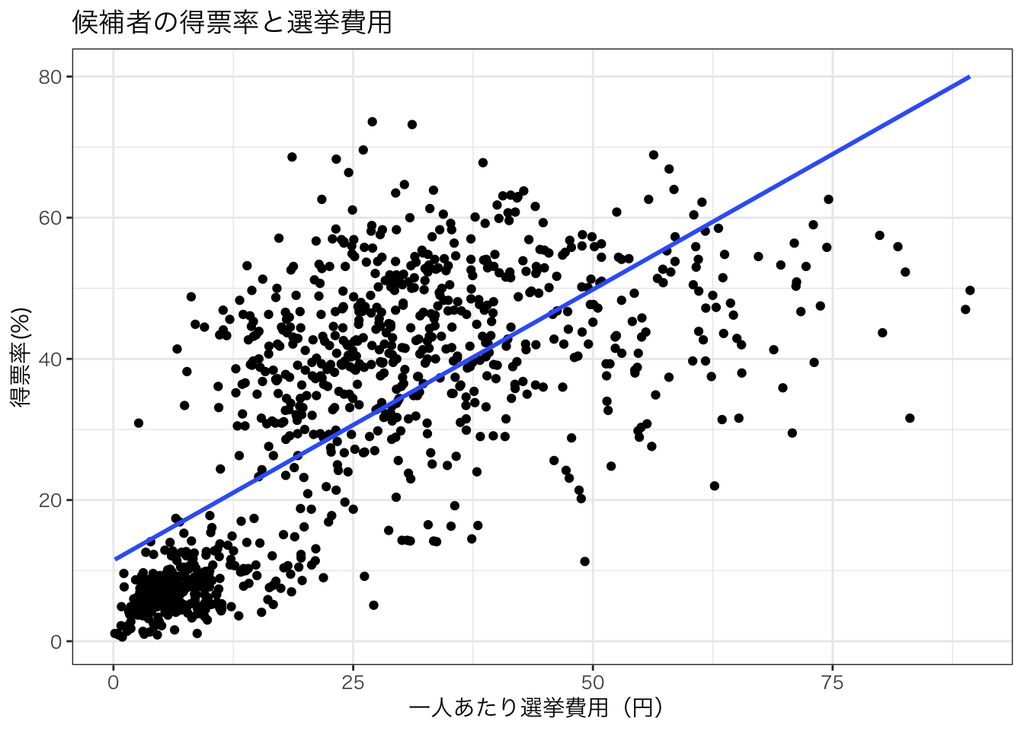

```r
hr05 %>%
  ggplot(aes(exppv, voteshare)) +
  geom_point() +
  labs(x = "一人あたり選挙費用（円）", y = "得票率(%)",
         title = "候補者の得票率と選挙費用") +
  theme_bw(base_family = "HiraKakuProN-W3") +
  geom_smooth(method = lm, se = FALSE)  # se = FALSE → 95% 信頼区間を消す
```

- `ldp` と `voteshare` の散布図を表示

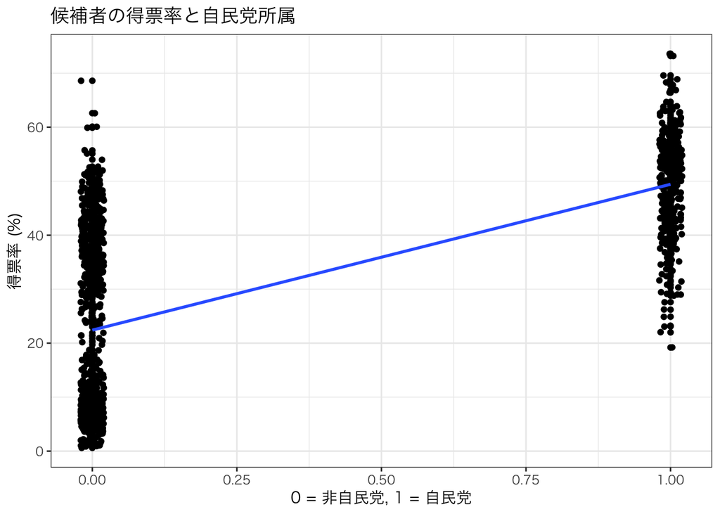

```r
hr05 %>%
  ggplot(aes(ldp, voteshare)) +
  geom_point() +
  labs(x = "0 = 非自民党, 1 = 自民党", y = "得票率 (%)",
         title = "候補者の得票率と自民党所属") +
  geom_jitter(width = 0.02) + # データを散らして表示
  theme_bw(base_family = "HiraKakuProN-W3") +
  geom_smooth(method = lm, se = FALSE)  # se = FALSE → 95% 信頼区間を消す
```

## 3.4 ふたつの回帰分析 (Model_5 & Model_6)

- `voteshare` と `exppv` の単回帰

```r
model_5 <- lm(voteshare ~ exppv,
              data = hr05)
```

- `voteshare` と `exppv + ldp` の**重回帰**

```r
model_6 <- lm(voteshare ~ exppv + ldp,
              data = hr05)
```

```r
stargazer(model_5, model_6, type = "html")
```

|  | *Dependent variable:* |  |
| --- | --- | --- |
|  | voteshare |  |
|  | (1) | (2) |
| exppv | 0.767*** | 0.565*** |
|  | (0.024) | (0.024) |
| ldp |  | 15.852*** |
|  |  | (0.961) |
| Constant | 11.453*** | 11.779*** |
|  | (0.727) | (0.644) |
| Observations | 985 | 985 |
| R<sup>2</sup> | 0.512 | 0.618 |
| Adjusted R<sup>2</sup> | 0.512 | 0.617 |
| Residual Std. Error | 13.422 (df = 983) | 11.883 (df = 982) |
| F Statistic | 1,031.634*** (df = 1; 983) | 794.203*** (df = 2; 982) |
| *Note:* | p<0.1; p<0.05; p<0.01 |  |

- `model_6`（右の列）の結果から、次の標本回帰関数 (`SRF`) の回帰式が得られる

$$\widehat{voteshare}\ = 11.78 + 0.57\cdot
exppv + 15.85\cdot ldp$$

- `exppv`（候補者が有権者一人当たりに使う選挙費用）が 1 円増えると、候補者の得票率が 0.57 % points 増える 1% で統計的に有意
- 自民党候補者は、そうでない候補者と比べると、平均して 15.85 % points 増える 1% で統計的に有意

**自民党候補者でない (ldp = 0) なら、**

$$\widehat{voteshare}\ = 11.78 + 0.57\cdot
exppv$$

**自民党候補者 (ldp = 1) なら、**

$$\widehat{voteshare}\ = 27.63 + 0.57
\cdot exppv$$

この結果を図で表すと、傾きが 0.57 の二本の平行線になる

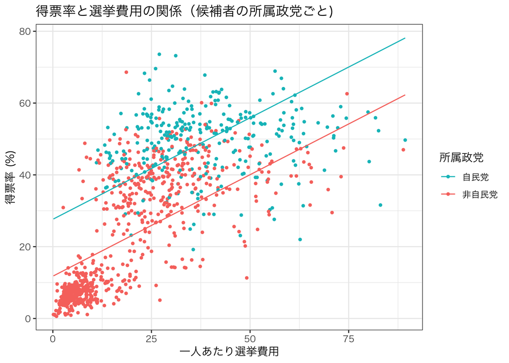

```r
## 予測値のデータフレームを作り pred と名前をつける
pred <- with(hr05, expand.grid(
  exppv = seq(min(exppv, na.rm=TRUE), max(exppv, na.rm=TRUE), length = 100),
  ldp = c(0,1)
))

## mutate を使って、新たな変数である予測値 (pred) を作り計算する
pred <- mutate(pred, voteshare = predict(model_6, newdata = pred))

## 散布図のドット (point) は観測値 (hr05) で描き、回帰直線は予測値 (pred) で描く
p3 <- ggplot(hr05, aes(x = exppv, y = voteshare, color = as.factor(ldp))) +
  geom_point(size = 1) + geom_line(data = pred)
p3 <- p3 + labs(x = "一人あたり選挙費用", y = "得票率 (%)")
p3 <- p3 + scale_color_discrete(name = "所属政党",
                                labels = c("非自民党","自民党")) + guides(color = guide_legend(reverse = TRUE)) +
  theme_bw(base_family = "HiraKakuProN-W3")

print(p3 + ggtitle("得票率と選挙費用の関係（候補者の所属政党ごと)"))
```

- **このモデルは 2 つの直線が平行になる（傾きが同じになる）ように設定**されている
- この図と分析結果から、候補者が有権者一人当たりに使う選挙費用が得票率を高めることと、自民党候補者なら16ポイント近く得票率が高いことがわかる
- しかし、選挙費用が得票率に与える影響の大きさが、自民党候補者とそうでない候補者の間でどれだけ違うのかはわからない このモデルでは、影響の大きさ（つまり傾き）は同じと想定しているため
- **交差項**をモデルに加えることで、自民党候補者とそうでない候補者それぞれの影響の大きさ（つまり傾き）を知ることができる

## 3.5 ダミー変数を含む回帰分析 (Model_6) のメカニズム

- ダミー変数を含めた上記重回帰分析 (`model_6`) のメカニズムを理解するため、ここでは次の3 段階の回帰分析を試してみる

**3 段階の回帰分析**  
Step1: 連続変数とダミー変数を使った単回帰分析 (`voteshare`, `ldp`)  
Step2: 連続変数と連続変数の単回帰分析 (`voteshare`, `exppv`)  
Step3: ダミー変数を含めた重回帰分析 (`voteshare`, `exppv`, `ldp`)

**Step1: 連続変数とダミー変数を使った単回帰分析**

- 候補者の得票率 (`voteshare`) を応答変数、候補者が自民党公認か否か (`ldp`) を説明変数とした回帰分析を考える
- `voteshare` は連続変数、`ldp` は カテゴリカル変数
- `voteshare` を縦軸、`ldp` を横軸にして両変数の相関関係を散布図で表す

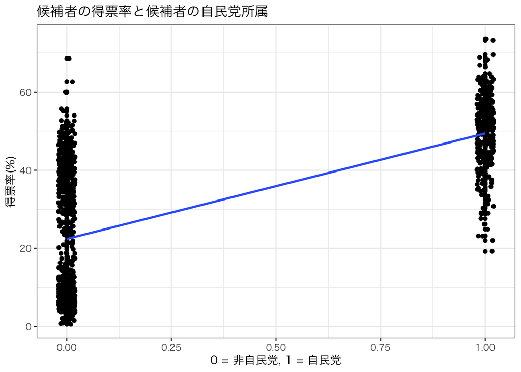

```r
ggplot(hr05, aes(ldp, voteshare)) +
  geom_point() +
  labs(x = "0 = 非自民党, 1 = 自民党", y = "得票率(%)",
         title = "候補者の得票率と候補者の自民党所属") +
  geom_jitter(width = 0.02) + # データを散らして表示
  geom_smooth(method = lm, se = FALSE) + # se = FALSE → 95% 信頼区間を消す
  theme_bw(base_family = "HiraKakuProN-W3")
```

- このモデルの回帰式は次のようになる

$$voteshare_i
\sim \mathrm{N}(\alpha_0 + \alpha_1 \cdot ldp_i,
\sigma^2)$$

- `lm()` を使って回帰式を求め、model_7と名前をつける

```r
model_7<- lm(voteshare ~ ldp, data = hr05)
```

- 回帰分析結果は `summary(　)` を使って表示できる

```r
summary(model_7)
```

```
Call:
lm(formula = voteshare ~ ldp, data = hr05)

Residuals:
    Min      1Q  Median      3Q     Max
-30.223 -14.313  -0.423  12.387  46.187

Coefficients:
            Estimate Std. Error t value Pr(>|t|)
(Intercept)  22.4132     0.5593   40.07   <2e-16 ***
ldp          27.0096     1.0329   26.15   <2e-16 ***
---
Signif. codes:  0 '***' 0.001 '**' 0.01 '*' 0.05 '.' 0.1 ' ' 1

Residual standard error: 14.79 on 987 degrees of freedom
Multiple R-squared:  0.4093,    Adjusted R-squared:  0.4087
F-statistic: 683.8 on 1 and 987 DF,  p-value: < 2.2e-16
```

- 以上の結果から、$\widehat{\alpha}_0= 22.41$, $\widehat{\alpha}_1 = 27$, $\widehat{\sigma} = 14.79$ が得られる
- この結果を踏まえると、`model_7` の回帰式は次のようになる

$$\widehat{voteshare}\ = 22.41 + 27 \cdot
ldp$$

**`model_7` の分析結果の解釈**

- F 検定の結果は最下行に示されており、 `p 値`は 2.2e-16 なので F 検定は 1% で有意
- 帰無仮説は「`ldp` の係数は 0 」
- $Pr ( > | t | )$ 下の「2e-16」が `p 値`  
  → `p 値`が 0.01 より小さいので、有意水準 $α = 0.01 (1 %) $で帰無仮説が棄却  
  → 候補者が自民党候補者だと (`ldp = 1)` 得票率が 27 %ポイント上がる
- `Adjusted R-squared` の値が 0.4087 → 応答変数 (`voteshare`) の分散の 40.87% が `ldp` によって説明できた
- R では `Signif. codes`: 以下に有意水準の表示基準が示され、`p 値`右上に付されたアステリスク数によって、帰無仮説が棄却される有意水準が示されている
- アステリスクク数が 3 つ・・・有意水準 $α = 0.001 (0.1\%)$ で有意
- アステリスクク数が 2 つ・・・有意水準 $α = 0.01 (1\%)$ で有意
- アステリスクク数が 1 つ・・・ 有意水準 $α = 0.05 (5\%)$ で有意
- `stargazer()`関数を使うと結果を見やすく表示できる
- R-Markdown で表示する際、`type = "html"` を指定するときにはチャンクオプションで ````{r, results = "asis"}` と指定する

```r
stargazer(model_7,
          type = "html",
          dep.var.labels = "Voteshare (%)", # 応答変数の名前
          title = "Table 1: LDP Affiliation and Voteshare in the 2005HR Election") # タイトル
```

**Table 1: LDP Affiliation and Voteshare in the 2005HR Election**

|  | *Dependent variable:* |
| --- | --- |
|  | Voteshare (%) |
| ldp | 27.010*** |
|  | (1.033) |
| Constant | 22.413*** |
|  | (0.559) |
| Observations | 989 |
| R<sup>2</sup> | 0.409 |
| Adjusted R<sup>2</sup> | 0.409 |
| Residual Std. Error | 14.788 (df = 987) |
| F Statistic | 683.759*** (df = 1; 987) |
| *Note:* | p<0.1; p<0.05; p<0.01 |

**ダミー変数を使った単回帰分析と t 検定**

$22.41 + 27.01 \cdot 0 = 22.41$

- 他方、予測値の式に `ldp = 1` を代入すると、**自民党候補者**の平均得票率（予測得票率）が得られる:

$$22.41 + 27.01 \cdot 1 =
49.42$$

- R で候補者ごとに平均得票率を求め、上で求めた2 つの予測値と一致するか確かめよう
- **非自民党候補者 (`ldp = 0`)** の平均得票率（予測得票率）

```r
hr05 %>%
  filter(ldp == 0) %>%  # filter を使って ldp = 0 だけのデータに限定
  with(mean(voteshare)) %>%    # with を使って votehshare の平均値を計算する
  round(2)                     # 小数点 2 位まで表示
```

```
[1] 22.41
```

- **自民党候補者 (ldp = 1)** の平均得票率（予測得票率）

```r
hr05 %>%
  filter(ldp == 1) %>%         # filter を使って ldp = 1 だけのデータに限定
  with(mean(voteshare)) %>%    # with を使って votehshare の平均値を計算する
  round(2)                     # 小数点 2 位まで表示
```

```
[1] 49.42
```

- 以上から、予測値は説明変数の値を与えられたときの、応答変数の平均値であることがわかる
- 実際に、自民党候補者と非自民党候補者の `voteshare` の平均を **`t 検定`すると回帰分析と同様の結果が得られる**
- `voteshare` は `unpaired` だから `default` で `t` 検定する

```r
t.test(hr05$voteshare[hr05$ldp == 1],
       hr05$voteshare[hr05$ldp == 0])
```

```
    Welch Two Sample t-test

data:  hr05$voteshare[hr05$ldp == 1] and hr05$voteshare[hr05$ldp == 0]
t = 32.446, df = 897.39, p-value < 2.2e-16
alternative hypothesis: true difference in means is not equal to 0
95 percent confidence interval:
 25.37584 28.64335
sample estimates:
mean of x mean of y
 49.42276  22.41316
```

**Step2: 連続変数と連続変数を使った単回帰分析**

- データフレーム `hr05` を使って、候補者の得票率 (`voteshare`) を応答変数、候補者が使う選挙費用 (`exppv`: 単位は円) を説明変数とした回帰分析を考える
- `voteshare` も `exppv` もどちらも連続変数
- `voteshare` を縦軸、`exppv` を横軸にして両変数の相関関係を散布図で表す

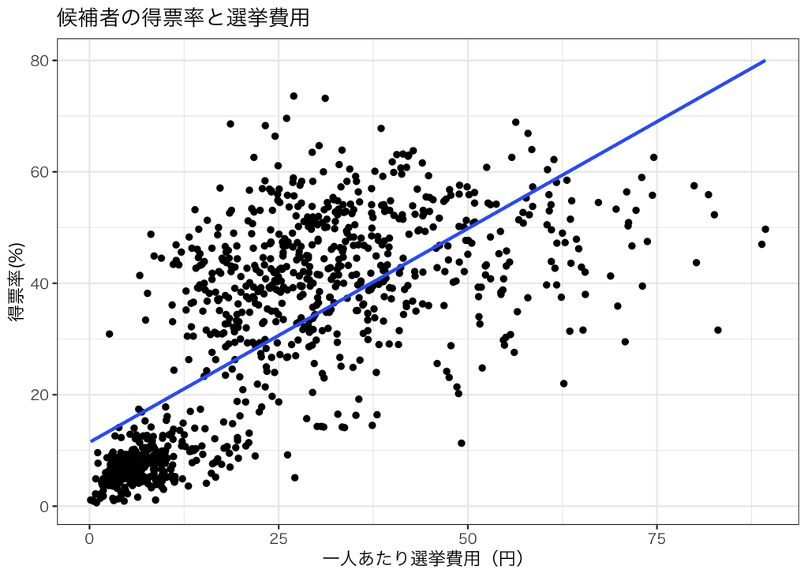

```r
ggplot(hr05, aes(exppv, voteshare)) +
  geom_point() +
  labs(x = "一人あたり選挙費用（円）", y = "得票率(%)",
         title = "候補者の得票率と選挙費用") +
  theme_bw(base_family = "HiraKakuProN-W3") +
  geom_smooth(method = lm, se = FALSE)  # se = FALSE → 95% 信頼区間を消す
```

- `lm()` を使って回帰式を求め、`model_8` と名前を付ける

```r
model_8 <- lm(voteshare ~ exppv, data = hr05)
```

- 回帰分析結果を表示する

```r
summary(model_8)
```

```
Call:
lm(formula = voteshare ~ exppv, data = hr05)

Residuals:
    Min      1Q  Median      3Q     Max
-43.596  -9.661  -3.493   9.909  42.851

Coefficients:
            Estimate Std. Error t value Pr(>|t|)
(Intercept) 11.45334    0.72744   15.74   <2e-16 ***
exppv        0.76745    0.02389   32.12   <2e-16 ***
---
Signif. codes:  0 '***' 0.001 '**' 0.01 '*' 0.05 '.' 0.1 ' ' 1

Residual standard error: 13.42 on 983 degrees of freedom
  (4 observations deleted due to missingness)
Multiple R-squared:  0.5121,    Adjusted R-squared:  0.5116
F-statistic:  1032 on 1 and 983 DF,  p-value: < 2.2e-16
```

- この結果を踏まえると、`model_8` の回帰式は次のようになる
  $$\widehat{voteshare}\ = 11.45 + 0.77 \cdot
  exppv$$

**model_8 の分析結果の解釈**

- $F$ 検定結果は最下行に示されており $p$ 値は 2.2e-16 なので $F$ 検定は 1% で有意
- 帰無仮説は「`exppv` の係数は 0 」
- $Pr ( > | t | )$ 下の「2e-16」が $p$ 値  
  → $p$ 検定値が 0.01 より小さいので、有意水準 $α = 0.01 (1 %)$ で帰無仮説が棄却  
  → 候補者が選挙費用を 1 円使うと、得票率が 0.767 %ポイント増える
- `Adjusted R-squared` の値が 0.512 → 応答変数 (`voteshare`) の分散の 51.2% が `exppv` によって説明できた
- `stargazer()`関数を使うと結果を見やすく表示できる
- `R-Markdown` で表示する際、`type = "html"` を指定するときにはチャンクオプションで ````{r, results = "asis"}` と指定する

```r
stargazer(model_8,
          type = "html",
          dep.var.labels = "Voteshare (%)", # 応答変数の名前
          title = "Table 2: Money and Voteshare in the 2005HR Election") # タイトル
```

**Table 2: Money and Voteshare in the 2005HR Election**

|  | *Dependent variable:* |
| --- | --- |
|  | Voteshare (%) |
| exppv | 0.767*** |
|  | (0.024) |
| Constant | 11.453*** |
|  | (0.727) |
| Observations | 985 |
| R<sup>2</sup> | 0.512 |
| Adjusted R<sup>2</sup> | 0.512 |
| Residual Std. Error | 13.422 (df = 983) |
| F Statistic | 1,031.634*** (df = 1; 983) |
| *Note:* | p<0.1; p<0.05; p<0.01 |

**Step3: ダミー変数を含めた重回帰分析**

**【ポイント：自民党候補者であることは候補者の得票率に影響したのか？】**

- 応答変数を `voteshare`（得票率）とし、`ldp`（自民党候補者）と exppv（有権者一人当たりの選挙費用）という2 つの説明変数で説明する重回帰分析を試みる
- モデルには `model_9` という名前をつける  
  **- model_9 の前提:「自民党候補者であるかどうかによって得票率が異なるにしても、選挙費用が得票率に与える影響（傾きの大きさ）は同じ」**

```r
model_9 <- lm(voteshare ~ ldp + exppv, data = hr05)

# 分析結果を表示する
summary(model_9)
```

```
Call:
lm(formula = voteshare ~ ldp + exppv, data = hr05)

Residuals:
    Min      1Q  Median      3Q     Max
-42.990  -8.828  -2.427   9.284  46.290

Coefficients:
            Estimate Std. Error t value Pr(>|t|)
(Intercept) 11.77885    0.64431   18.28   <2e-16 ***
ldp         15.85224    0.96087   16.50   <2e-16 ***
exppv        0.56538    0.02444   23.13   <2e-16 ***
---
Signif. codes:  0 '***' 0.001 '**' 0.01 '*' 0.05 '.' 0.1 ' ' 1

Residual standard error: 11.88 on 982 degrees of freedom
  (4 observations deleted due to missingness)
Multiple R-squared:  0.618, Adjusted R-squared:  0.6172
F-statistic: 794.2 on 2 and 982 DF,  p-value: < 2.2e-16
```

- この結果を踏まえると、`model_9` の回帰式は次のようになる

$$\widehat{voteshare}\ = 11.78 + 15.85
\cdot ldp\ + 0.565 \cdot exppv`$$

- `model_9` の分析結果の解釈
- $F$ 検定結果は最下行に示されており、$p$ 値は 2.2e-16 なので$F$ 検定は 1% で有意

帰無仮説は次の 2 つ：

1. $H_0$:「候補者が自民党公認か否かという変数 (`ldp`) の係数は 0」
2. $H_0$:「候補者が使う有権者一人あたりの選挙費用 (`exppv`) の係数は 0」
- $Pr ( > | t | )$ 下の「2e-16」が $p$ 値  
  → 両変数の $p$値が 0.01 より小さいので、有意水準 $α$ = 0.01 (1 %) で帰無仮説が棄却  
  → `exppv` の値を平均に固定した時、自民党公認候補者だと (`ldp = 1`) 得票率が 15.85 %ポイント上がる  
  → `ldp` の値を平均に固定した時、候補者が有権者一人当たりに選挙費用を 1 円使うと、得票率が 0.565 %ポイント上がる
- 切片の係数が 11.78 だから、有権者一人当たりに選挙費用 `expp` と 自民党ダミー `ldp` の両者が 0 のとき、得票率の予測値は 11.78 %ポイント
- `Adjusted R-squared` の値が 0.6172 → 応答変数 (`voteshare`) の分散の 61.72% が `exppv` と `ldp` によって説明できた
- **`ldp` の係数 15.85 とはどういう意味か？**  
  → 「`ldp` ダミーが 1 単位増えると、得票率が 15.85%ポイント上昇する」  
  ＝「自民党公認候補者は、そうでない候補者と比べて得票率が 15.85%ポイント高い」
- `model_9` の結果を図示すると、次のようになる

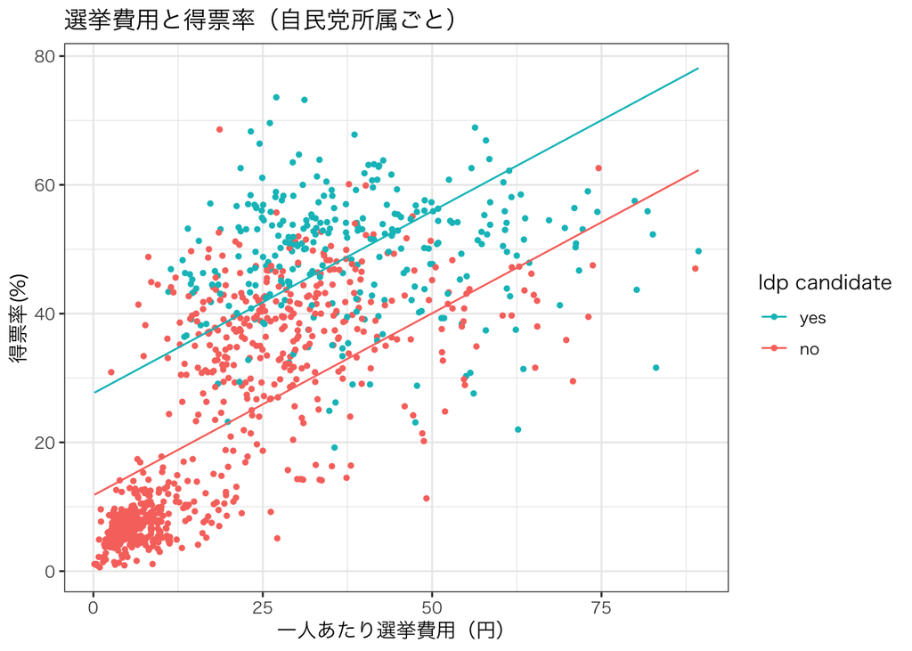

```r
## 予測値のデータフレームを作り pred と名前をつける
pred <- with(hr05, expand.grid(
  exppv = seq(min(exppv, na.rm=TRUE), max(exppv, na.rm=TRUE), length = 100),
  ldp = c(0,1)
))

## mutate を使って、新たな変数である予測値 (pred) を作り計算する
pred <- mutate(pred, voteshare = predict(model_9, newdata = pred))

## 散布図のドット (point) は観測値 (hr05) で描き、回帰直線は予測値 (pred) で描く
p9 <- ggplot(hr05, aes(x = exppv, y = voteshare, color = as.factor(ldp))) +
  geom_point(size = 1) + geom_line(data = pred)
p9 <- p9 + labs(x = "一人あたり選挙費用（円）", y = "得票率(%)")
p9 <- p9 + scale_color_discrete(name = "ldp candidate",
                                labels = c("no","yes")) + guides(color = guide_legend(reverse = TRUE)) +
theme_bw(base_family = "HiraKakuProN-W3")

print(p9 + ggtitle("選挙費用と得票率（自民党所属ごと）"))
```

- このモデルは 2 つの直線が平行になる（傾きが同じになる）ように設定されている

**`model_9` の回帰**

$$\widehat{voteshare} = 11.78 + 15.85
\cdot ldp\ + 0.565 \cdot exppv$$

- `model_9` の回帰式に、非自民党候補者 (`ldp = 0`) を代入すると、トマト色の回帰式が得られる

$$\widehat{voteshare}\ = 11.78 + 0.565
\cdot exppv$$

- `model_9` の回帰式に、自民党候補者 (`ldp = 1`) を代入すると、青色の回帰式が得られる

$$\widehat{voteshare}\ = 27.63 + 0.565
\cdot exppv$$

- `ldp` ダミーの値が異なる2 つの式を比較すると、**違うのは切片だけで、傾きは同じ**
- 2 つの回帰直線は平行だが、その切片は異なる(11.78 と 27.63)
- 自民党候補者であるという要因が、回帰直線を上方に移動させている  
  （= 自民党候補者は、そうでない候補者と比べると、平均して得票率が 15.85ポイント増える)
- 全体的に自民党公認候補者の得票率（青色）が、そうでない候補者の得票率（トマト色）より高い
- 2 本の回帰直線は、それぞれ自民党公認候補者（青色）とそうでない候補者（トマト色）の、選挙費用と得票率の関係を捉えている
- **ダミー変数を説明変数に加えると、ダミー変数の値によって回帰直線が平行移動するような変化（つまり、自民党候補者であるか否かという要因は候補者の得票率に影響したのかということ）を捉えることができる**
- `stagazer()` を使うと、3 つの統計モデル (`model_7`, `model_8`, `model_9`)の分析結果を一つの表で表すこともできる
- `stargazer(model_7, model_8, model_9, type = "html")`という簡単なコマンドでも結果を表示できる
- `R-Markdown` で表示する際、`type = "html"` を指定するときにはチャンクオプションで ````{r, results = "asis"}` と指定する

```r
stargazer(model_7, model_8, model_9,
          type = "html",
          dep.var.labels = "Voteshare (%)", # 応答変数の名前
          title = "Table 4: 選挙費用と得票率（自民党所属ごと）") # タイトル
```

**Table 4: 選挙費用と得票率（自民党所属ごと）**

|  | *Dependent variable:* |  |  |
| --- | --- | --- | --- |
|  | Voteshare (%) |  |  |
|  | (1) | (2) | (3) |
| ldp | 27.010*** |  | 15.852*** |
|  | (1.033) |  | (0.961) |
| exppv |  | 0.767*** | 0.565*** |
|  |  | (0.024) | (0.024) |
| Constant | 22.413*** | 11.453*** | 11.779*** |
|  | (0.559) | (0.727) | (0.644) |
| Observations | 989 | 985 | 985 |
| R<sup>2</sup> | 0.409 | 0.512 | 0.618 |
| Adjusted R<sup>2</sup> | 0.409 | 0.512 | 0.617 |
| Residual Std. Error | 14.788 (df = 987) | 13.422 (df = 983) | 11.883 (df = 982) |
| F Statistic | 683.759*** (df = 1; 987) | 1,031.634*** (df = 1; 983) | 794.203*** (df = 2; 982) |
| *Note:* | p<0.1; p<0.05; p<0.01 |  |  |

#### `modelsummary()` を使った結果の表示

・`stargazer` の代わりに、`modelsummary()` を使って、分析結果を表示させる  
・`modelsummary` パッケージを読み込む

```r
library(modelsummary)
```

```r
msummary(list(model_7, model_8, model_9),
  gof_omit = "IC|F|RMSE|Log",
    stars = TRUE)
```

|  | (1) | (2) | (3) |
| --- | --- | --- | --- |
| (Intercept) | 22.413*** | 11.453*** | 11.779*** |
|  | (0.559) | (0.727) | (0.644) |
| ldp | 27.010*** |  | 15.852*** |
|  | (1.033) |  | (0.961) |
| exppv |  | 0.767*** | 0.565*** |
|  |  | (0.024) | (0.024) |
| Num.Obs. | 989 | 985 | 985 |
| R2 | 0.409 | 0.512 | 0.618 |
| R2 Adj. | 0.409 | 0.512 | 0.617 |

+ p < 0.1, * p < 0.05, ** p < 0.01, *** p < 0.001

## 3.6 95 パーセント信頼区間を加えた散布図

- 上記の散布図に 95 パーセント信頼区間を加えてみる
- 信頼区間を求めるために標準誤差を利用する
- 標準誤差は t 分布に従うので、`qt( )` で分布の 95% が収まる範囲を求める

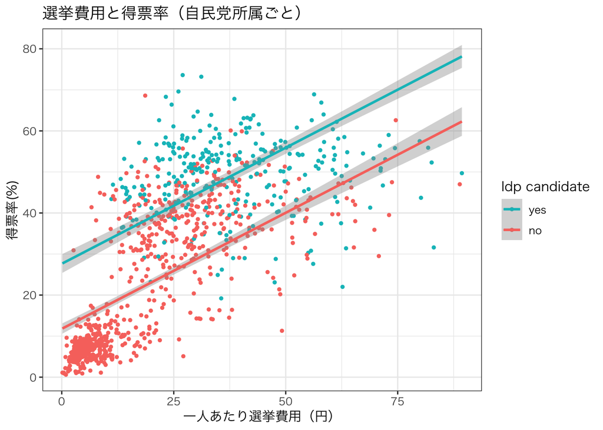

```r
## 信頼区間の下限と上限を計算する
## まず、予測値 (pred) と標準誤差 (err) を求める
err <- predict(model_9, newdata = pred, se.fit = TRUE)

## 予測値と標準誤差を使って信頼区間 (pred$lower, pred$upper) を求める
pred$lower <- err$fit + qt(0.025, df = err$df) * err$se.fit
pred$upper <- err$fit + qt(0.975, df = err$df) * err$se.fit

p9.ci95 <- p9 +
  geom_smooth(data = pred, aes(ymin = lower, ymax = upper), stat ="identity")

# 作成した図を表示する
print(p9.ci95 + ggtitle("選挙費用と得票率（自民党所属ごと）"))
```

## 3.7 頑強な標準誤差を使った回帰分析

- R上の回帰分析で使う `lm()` では、不均一分散に対応できない
- 結果変数の分散が一定でないと  
  → `lm()`が計算する標準誤差は回帰係数のばらつきを過小評価してしまう
- 不均一分散と理論的な対処法に関する詳細に関しては [森氏幸之助`「回帰分析ではlm()ではなく estimtr::lm_robust()を使おう」`](https://speakerdeck.com/dropout009/tokyor100)参照

#### 解決策 → `estimatr::lm_robust()` を使う

```r
library(estimatr)
```

```r
DT::datatable(hr05)
```

|  | voteshare | exppv | ldp | district |
| --- | --- | --- | --- | --- |
| 1 | 3.6 | 13.06223490098804 | 0 | aichi_1 |
| 2 | 7.4 | 6.048290727680295 | 0 | aichi_1 |
| 3 | 39.1 | 40.02492173763288 | 1 | aichi_1 |
| 4 | 50 | 17.04648520723208 | 0 | aichi_1 |
| 5 | 8.9 | 5.508424810376897 | 0 | aichi_2 |
| 6 | 39.1 | 14.44830534167666 | 1 | aichi_2 |
| 7 | 52 | 30.24996654111619 | 0 | aichi_2 |
| 8 | 3.8 | 1.743847172268302 | 0 | aichi_3 |
| 9 | 9 | 4.297662836186483 | 0 | aichi_3 |
| 10 | 38.2 | 15.83723857448503 | 1 | aichi_3 |

[output cut: 979 more lines]

```r
model_9 <- lm_robust(voteshare ~ ldp + exppv,
  data = hr05)
```

```r
model_10 <- lm_robust(voteshare ~ ldp + exppv,
  data = hr05,
  clusters = district)
```

- `stargazer`を使って結果を表記してみる

```r
stargazer::stargazer(model_9, model_10,
  type = "text")
```

```
% Error: Unrecognized object type.
% Error: Unrecognized object type.
```

- エラーのため、結果が表示されない
- `stargazer` は `lm_robust()` に対応していない

#### 解決策 => `lm_robust()` に対応している `modelsummary` を使う

```r
library(modelsummary)
```

```r
modelsummary(list(model_9, model_10),
  stars = TRUE,               # アステリスクを表示させる
  statistic = 'std.error',    # 標準誤差はデフォルト
  gof_omit = "IC|F|RMSE|Log") # 非表示の設定)
```

|  | (1) | (2) |
| --- | --- | --- |
| (Intercept) | 11.779*** | 11.779*** |
|  | (0.632) | (0.500) |
| ldp | 15.852*** | 15.852*** |
|  | (0.933) | (0.852) |
| exppv | 0.565*** | 0.565*** |
|  | (0.026) | (0.025) |
| Num.Obs. | 985 | 985 |
| R2 | 0.618 | 0.618 |
| R2 Adj. | 0.617 | 0.617 |
| Std.Errors |  | by: district |

+ p < 0.1, * p < 0.05, ** p < 0.01, *** p < 0.001

#### 変数名の変更とタイトル

- 変数名の変更は `coef_map` を使う
- あらかじめ、変数名の対応表をベクトルに指定しておく
- 変数を表示する順番も指定できる

```r
var_nam = c("ldp"       = "自民党ダミー",
            "exppv"     = "一人あたり選挙費（円）",
            "(Intercept)" = "Constant")
```

```r
modelsummary(list(model_9, model_10),
  stars = TRUE,               # アステリスクを表示させる
  statistic = 'std.error',    # 標準誤差はデフォルト
  gof_omit = "IC|F|RMSE|Log", # 非表示の設定
  title = "2005年総選挙における得票率の分析",
  coef_map = var_nam)
```

2005年総選挙における得票率の分析

|  | (1) | (2) |
| --- | --- | --- |
| 自民党ダミー | 15.852*** | 15.852*** |
|  | (0.933) | (0.852) |
| 一人あたり選挙費（円） | 0.565*** | 0.565*** |
|  | (0.026) | (0.025) |
| Constant | 11.779*** | 11.779*** |
|  | (0.632) | (0.500) |
| Num.Obs. | 985 | 985 |
| R2 | 0.618 | 0.618 |
| R2 Adj. | 0.617 | 0.617 |
| Std.Errors |  | by: district |

+ p < 0.1, * p < 0.05, ** p < 0.01, *** p < 0.001

出力したい統計量の設定 ・`statistic = 'p.value'`・・・p値を出力したい時  
・`statistic = 'statistic'`・・・t値を出力したい時  
・`statistic = 'conf.int'`・・・95%信頼区間を出力したい時  
・`statistic = 'conf.int', conf_level = .99`・・・99%信頼区間を出力したい時

# 4. Exercise

- [`hr96-26.csv`](https://asanoucla.github.io/hr96-26.csv) は1996年に衆院選挙に小選挙区が導入されて以来実施された 11 回の衆議院選挙（1996, 2000, 2003, 2005, 2009, 2012, 2014, 2017, 2021, 2024, 2026）の結果のデータ
- このデータの中から2009年の衆議院選挙データだけ取り出し、次の 3 つの変数 (`voteshare`, `exppv`, `dpj`) を使って重回帰分析を行いなさい

| 変数の種類 | 変数名 | 詳細 |
| --- | --- | --- |
| 応答変数 | `voteshare` | 得票率 (%) |
| 説明変数 | `exppv` | 有権者一人当たりに候補者が費やした選挙費用（円） |
| 制御変数 | `dpj` | 民主党ダミー（民主党候補者 = 1、それ以外 = 0） |

**注意：`dpj ダミー`は自分で作成すること**  
**Q1:** `stargazer()`を使って、2009年の衆議院選挙の 3 つの変数 (`voteshare`, `exppv`, `dpj`) の記述統計を表示させなさい  
**Q2:** `exppv` と `voteshare` の散布図を描きなさい その際、回帰直線も表示すること  
**Q3:** `dpj` と `voteshare` の散布図を描きなさい その際、回帰直線も表示すること  
**Q4:** `voteshare` を応答変数、`exppv` と `dpj` を説明変数とした重回帰分析を実行し、その重回帰式を示し、重回帰分析結果を解釈しなさい  
**Q5:** `voteshare` を応答変数、`exppv` と `dpj` を説明変数とした散布図を描きなさい その際、観測値と回帰直線はダミー変数 (`dpj`) で色分けすること  
（白黒で描く場合には、散布図のドットの形を変えたり、回帰直線の種類を 2 種類使うこと）

**参考文献**

飯田健『計量政治分析』共立出版、2013年.

Ellis Goldberg (1996), *Thinking about How Democracy Works*, Politics & Society, Vol. 24, pp.7-18.

[宋財泫 (Jaehyun Song)- 矢内勇生 (Yuki Yanai)「私たちのR: ベストプラクティスの探究」](https://www.jaysong.net/RBook/)

[土井翔平（北海道大学公共政策大学院）「Rで計量政治学入門」](https://shohei-doi.github.io/quant_polisci/data-import.html)

[矢内勇生（高知工科大学）授業一覧](http://yukiyanai.github.io/teaching/)

浅野正彦, 矢内勇生.『Rによる計量政治学』オーム社、2018年

浅野正彦, 中村公亮.『初めてのRStudio』オーム社、2018年

Winston Chang, R Graphics Cookbook, O’Reilly Media, 2012.

Kieran Healy, DATA VISUALIZATION, Princeton, 2019

Kosuke Imai, Quantitative Social Science: An Introduction, Princeton University Press, 2017